# Analysis of Data Science Job Postings on Glassdoor

### The goal of this project is to identify trends, patterns and key factors that influence job postings and to analyze which idustries, sectors or companies hire data scientists, data anlyst, Business Intelligenece developer (data jobs) .Understand the pay range across diffrent sector and industry.

### Project Goals :

- Clean and transform the raw/uncleaned data for analysis and visualization
- Perform Exploratory data analysis (EDA) to identify trends, patterns in the data

### Data Cleaning and Transformation

```python
# importing the relevant libraries

import numpy as np
import pandas as pd
pd.options.mode.chained_assignment = None  # default='warn'
import matplotlib.pyplot as plt
import re
```

```python
# Importing dataset
df = pd.read_csv("C:/Users/Lenovo/Desktop/Datasets/Uncleaned_DS_jobs.csv")
pd.set_option("display.max_rows",None)
df
```

|  | index | Job Title | Salary Estimate | Job Description | Rating | Company Name | Location | Headquarters | Size | Founded | Type of ownership | Industry | Sector | Revenue | Competitors |
| --- | --- | --- | --- | --- | --- | --- | --- | --- | --- | --- | --- | --- | --- | --- | --- |
| 0 | 0 | Sr Data Scientist | $137K-$171K (Glassdoor est.) | Description\n\nThe Senior Data Scientist is re... | 3.1 | Healthfirst\n3.1 | New York, NY | New York, NY | 1001 to 5000 employees | 1993 | Nonprofit Organization | Insurance Carriers | Insurance | Unknown / Non-Applicable | EmblemHealth, UnitedHealth Group, Aetna |
| 1 | 1 | Data Scientist | $137K-$171K (Glassdoor est.) | Secure our Nation, Ignite your Future\n\nJoin ... | 4.2 | ManTech\n4.2 | Chantilly, VA | Herndon, VA | 5001 to 10000 employees | 1968 | Company - Public | Research & Development | Business Services | $1 to $2 billion (USD) | -1 |
| 2 | 2 | Data Scientist | $137K-$171K (Glassdoor est.) | Overview\n\n\nAnalysis Group is one of the lar... | 3.8 | Analysis Group\n3.8 | Boston, MA | Boston, MA | 1001 to 5000 employees | 1981 | Private Practice / Firm | Consulting | Business Services | $100 to $500 million (USD) | -1 |
| 3 | 3 | Data Scientist | $137K-$171K (Glassdoor est.) | JOB DESCRIPTION:\n\nDo you have a passion for ... | 3.5 | INFICON\n3.5 | Newton, MA | Bad Ragaz, Switzerland | 501 to 1000 employees | 2000 | Company - Public | Electrical & Electronic Manufacturing | Manufacturing | $100 to $500 million (USD) | MKS Instruments, Pfeiffer Vacuum, Agilent Tech... |
| 4 | 4 | Data Scientist | $137K-$171K (Glassdoor est.) | Data Scientist\nAffinity Solutions / Marketing... | 2.9 | Affinity Solutions\n2.9 | New York, NY | New York, NY | 51 to 200 employees | 1998 | Company - Private | Advertising & Marketing | Business Services | Unknown / Non-Applicable | Commerce Signals, Cardlytics, Yodlee |
| 5 | 5 | Data Scientist | $137K-$171K (Glassdoor est.) | About Us:\n\nHeadquartered in beautiful Santa ... | 4.2 | HG Insights\n4.2 | Santa Barbara, CA | Santa Barbara, CA | 51 to 200 employees | 2010 | Company - Private | Computer Hardware & Software | Information Technology | Unknown / Non-Applicable | -1 |
| 6 | 6 | Data Scientist / Machine Learning Expert | $137K-$171K (Glassdoor est.) | Posting Title\nData Scientist / Machine Learni... | 3.9 | Novartis\n3.9 | Cambridge, MA | Basel, Switzerland | 10000+ employees | 1996 | Company - Public | Biotech & Pharmaceuticals | Biotech & Pharmaceuticals | $10+ billion (USD) | -1 |
| 7 | 7 | Data Scientist | $137K-$171K (Glassdoor est.) | Introduction\n\nHave you always wanted to run ... | 3.5 | iRobot\n3.5 | Bedford, MA | Bedford, MA | 1001 to 5000 employees | 1990 | Company - Public | Consumer Electronics & Appliances Stores | Retail | $1 to $2 billion (USD) | -1 |
| 8 | 8 | Staff Data Scientist - Analytics | $137K-$171K (Glassdoor est.) | Intuit is seeking a Staff Data Scientist to co... | 4.4 | Intuit - Data\n4.4 | San Diego, CA | Mountain View, CA | 5001 to 10000 employees | 1983 | Company - Public | Computer Hardware & Software | Information Technology | $2 to $5 billion (USD) | Square, PayPal, H&R Block |
| 9 | 9 | Data Scientist | $137K-$171K (Glassdoor est.) | Ready to write the best chapter of your career... | 3.6 | XSELL Technologies\n3.6 | Chicago, IL | Chicago, IL | 51 to 200 employees | 2014 | Company - Private | Enterprise Software & Network Solutions | Information Technology | Unknown / Non-Applicable | -1 |
| 10 | 10 | Data Scientist | $137K-$171K (Glassdoor est.) | Join our team dedicated to developing and exec... | 4.5 | Novetta\n4.5 | Herndon, VA | Mc Lean, VA | 501 to 1000 employees | 2012 | Company - Private | Enterprise Software & Network Solutions | Information Technology | $100 to $500 million (USD) | Leidos, CACI International, Booz Allen Hamilton |
| 11 | 11 | Data Scientist | $137K-$171K (Glassdoor est.) | About Us\n\n\nInterested in working for a huma... | 4.7 | 1904labs\n4.7 | Saint Louis, MO | Saint Louis, MO | 51 to 200 employees | 2016 | Company - Private | IT Services | Information Technology | Unknown / Non-Applicable | Slalom, Daugherty Business Solutions |
| 12 | 12 | Data Scientist - Statistics, Early Career | $137K-$171K (Glassdoor est.) | *Organization and Job ID**\nJob ID: 310918\n\n... | 3.7 | PNNL\n3.7 | Richland, WA | Richland, WA | 1001 to 5000 employees | 1965 | Government | Energy | Oil, Gas, Energy & Utilities | $500 million to $1 billion (USD) | Oak Ridge National Laboratory, National Renewa... |
| 13 | 13 | Data Modeler | $137K-$171K (Glassdoor est.) | POSITION PURPOSE:\n\nThe Data Architect/Data M... | 3.1 | Old World Industries\n3.1 | Northbrook, IL | Northbrook, IL | 201 to 500 employees | 1973 | Company - Private | Chemical Manufacturing | Manufacturing | $1 to $2 billion (USD) | -1 |
| 14 | 14 | Data Scientist | $137K-$171K (Glassdoor est.) | Position Description:\n\nWant to make a differ... | 3.4 | Mathematica Policy Research\n3.4 | Washington, DC | Princeton, NJ | 1001 to 5000 employees | 1986 | Company - Private | Consulting | Business Services | $100 to $500 million (USD) | -1 |
| 15 | 15 | Experienced Data Scientist | $137K-$171K (Glassdoor est.) | *******Please Apply using this link: https://a... | 4.4 | Guzman & Griffin Technologies (GGTI)\n4.4 | Washington, DC | Mays Landing, NJ | 1 to 50 employees | 1997 | Company - Private | Federal Agencies | Government | Unknown / Non-Applicable | -1 |
| 16 | 16 | Data Scientist - Contract | $137K-$171K (Glassdoor est.) | We are an ambitious, well-funded startup with ... | 4.1 | Upside Business Travel\n4.1 | Remote | Washington, DC | 51 to 200 employees | 2015 | Company - Private | Internet | Information Technology | Unknown / Non-Applicable | -1 |
| 17 | 17 | Data Scientist | $137K-$171K (Glassdoor est.) | Job Success Profile\n\nData Scientist\n\nBuckm... | 3.5 | Buckman\n3.5 | Memphis, TN | Memphis, TN | 1001 to 5000 employees | 1945 | Company - Private | Chemical Manufacturing | Manufacturing | $500 million to $1 billion (USD) | -1 |
| 18 | 18 | Data Analyst II | $137K-$171K (Glassdoor est.) | The Data Analyst II is responsible for data en... | 4.2 | Insight Enterprises, Inc.\n4.2 | Plano, TX | Tempe, AZ | 5001 to 10000 employees | 1988 | Company - Public | Enterprise Software & Network Solutions | Information Technology | $5 to $10 billion (USD) | CDW, PCM, SHI International |
| 19 | 19 | Medical Lab Scientist | $137K-$171K (Glassdoor est.) | Responsibilities\n\n\nThe Medical Laboratory S... | 3.5 | Tower Health\n3.5 | West Grove, PA | Reading, PA | 5001 to 10000 employees | 2017 | Nonprofit Organization | Health Care Services & Hospitals | Health Care | Unknown / Non-Applicable | -1 |
| 20 | 20 | Data Scientist | $137K-$171K (Glassdoor est.) | Role Description\nAs a data scientist at Tripl... | 3.2 | Triplebyte\n3.2 | New York, NY | San Francisco, CA | 51 to 200 employees | 2015 | Company - Private | Computer Hardware & Software | Information Technology | Unknown / Non-Applicable | -1 |
| 21 | 21 | Data Scientist/Machine Learning | $137K-$171K (Glassdoor est.) | PulsePoint™, a global programmatic advertising... | 4.3 | PulsePoint\n4.3 | New York, NY | New York, NY | 51 to 200 employees | 2011 | Company - Private | Internet | Information Technology | $100 to $500 million (USD) | Crossix Solutions Inc., AppNexus, The Trade Desk |
| 22 | 22 | Human Factors Scientist | $137K-$171K (Glassdoor est.) | Human Factors Scientist\nID\n\n3336\n\nLocatio... | 3.5 | Exponent\n3.5 | Phoenix, AZ | Menlo Park, CA | 1001 to 5000 employees | 1967 | Company - Public | Consulting | Business Services | $100 to $500 million (USD) | -1 |
| 23 | 23 | Business Intelligence Analyst I- Data Insights | $137K-$171K (Glassdoor est.) | Position Summary\n\nIndividuals within the\nBu... | 3.5 | Guardian Life\n3.5 | Appleton, WI | New York, NY | 5001 to 10000 employees | 1860 | Company - Private | Insurance Carriers | Insurance | $5 to $10 billion (USD) | Northwestern Mutual |
| 24 | 24 | Data Scientist | $137K-$171K (Glassdoor est.) | What’s significantly better than working on a ... | 3.4 | Spectrum Communications and Consulting\n3.4 | Chicago, IL | Chicago, IL | 51 to 200 employees | 1992 | Company - Private | Advertising & Marketing | Business Services | $10 to $25 million (USD) | -1 |
| 25 | 25 | Data Scientist | $137K-$171K (Glassdoor est.) | Job Description\n\n\nOversight is a leading pr... | 4.7 | Oversight Systems\n4.7 | Atlanta, GA | Atlanta, GA | 51 to 200 employees | 2003 | Company - Private | Computer Hardware & Software | Information Technology | $25 to $50 million (USD) | -1 |
| 26 | 26 | Data Scientist - Risk | $137K-$171K (Glassdoor est.) | Job Title: Data Scientist (Risk)\n\nLocation: ... | 4.2 | LSQ\n4.2 | Orlando, FL | Orlando, FL | 51 to 200 employees | 1996 | Company - Private | Investment Banking & Asset Management | Finance | $100 to $500 million (USD) | -1 |
| 27 | 27 | Data Scientist-Human Resources | $137K-$171K (Glassdoor est.) | Lexington, MA, US\n\n#job-location.job-locatio... | 3.8 | MIT Lincoln Laboratory\n3.8 | Lexington, MA | Lexington, MA | 1001 to 5000 employees | 1951 | Nonprofit Organization | Aerospace & Defense | Aerospace & Defense | Unknown / Non-Applicable | -1 |
| 28 | 28 | Data Scientist | $137K-$171K (Glassdoor est.) | Kingfisher Systems, Inc. specializes in provid... | 4.5 | Kingfisher Systems\n4.5 | McLean, VA | Falls Church, VA | 51 to 200 employees | 2005 | Company - Private | Federal Agencies | Government | $25 to $50 million (USD) | -1 |
| 29 | 29 | Data Scientist | $137K-$171K (Glassdoor est.) | Formation provides personalization for the lar... | 2.8 | Formation\n2.8 | San Francisco, CA | San Francisco, CA | 51 to 200 employees | 2015 | Company - Private | Enterprise Software & Network Solutions | Information Technology | Unknown / Non-Applicable | -1 |

[output cut: 642 more lines]

```python
# Checking total count of rows and columns
df.shape
```

```
(672, 15)
```

```python
# Checking the total non-null values count and columns datatype
df.info()
```

```
<class 'pandas.core.frame.DataFrame'>
RangeIndex: 672 entries, 0 to 671
Data columns (total 15 columns):
 #   Column             Non-Null Count  Dtype
---  ------             --------------  -----
 0   index              672 non-null    int64
 1   Job Title          672 non-null    object
 2   Salary Estimate    672 non-null    object
 3   Job Description    672 non-null    object
 4   Rating             672 non-null    float64
 5   Company Name       672 non-null    object
 6   Location           672 non-null    object
 7   Headquarters       672 non-null    object
 8   Size               672 non-null    object
 9   Founded            672 non-null    int64
 10  Type of ownership  672 non-null    object
 11  Industry           672 non-null    object
 12  Sector             672 non-null    object
 13  Revenue            672 non-null    object
 14  Competitors        672 non-null    object
dtypes: float64(1), int64(2), object(12)
memory usage: 78.9+ KB
```

```python
#removing the index, founded and revenue columns as these columns are not needed for analysis
df.drop(columns=['index','Founded','Revenue'],axis = 1,inplace = True)
```

```python
# Let's verify the columns now after dropping columns
df.info()
```

```
<class 'pandas.core.frame.DataFrame'>
RangeIndex: 672 entries, 0 to 671
Data columns (total 12 columns):
 #   Column             Non-Null Count  Dtype
---  ------             --------------  -----
 0   Job Title          672 non-null    object
 1   Salary Estimate    672 non-null    object
 2   Job Description    672 non-null    object
 3   Rating             672 non-null    float64
 4   Company Name       672 non-null    object
 5   Location           672 non-null    object
 6   Headquarters       672 non-null    object
 7   Size               672 non-null    object
 8   Type of ownership  672 non-null    object
 9   Industry           672 non-null    object
 10  Sector             672 non-null    object
 11  Competitors        672 non-null    object
dtypes: float64(1), object(11)
memory usage: 63.1+ KB
```

```python
#Using lambda function to change the column name in standerdized format to ensure consistency
df.columns = df.columns.map(lambda x : x.replace("-", "_").replace(" ", "_"))
df.rename(columns= lambda header: header.lower(),inplace = True)
df.info()
```

```
<class 'pandas.core.frame.DataFrame'>
RangeIndex: 672 entries, 0 to 671
Data columns (total 12 columns):
 #   Column             Non-Null Count  Dtype
---  ------             --------------  -----
 0   job_title          672 non-null    object
 1   salary_estimate    672 non-null    object
 2   job_description    672 non-null    object
 3   rating             672 non-null    float64
 4   company_name       672 non-null    object
 5   location           672 non-null    object
 6   headquarters       672 non-null    object
 7   size               672 non-null    object
 8   type_of_ownership  672 non-null    object
 9   industry           672 non-null    object
 10  sector             672 non-null    object
 11  competitors        672 non-null    object
dtypes: float64(1), object(11)
memory usage: 63.1+ KB
```

we have dropped the unnecessary columns and transformrd columns name in standerdized format, now let's verify each and every column data and find out the duplicates, missing/null values

### Job Title

```python
# Unique entries in job title column
df['job_title'].nunique()
```

```
172
```

```python
# Removing leading or trailing whitespaces
df['job_title'].str.strip()
```

```
0                                      Sr Data Scientist
1                                         Data Scientist
2                                         Data Scientist
3                                         Data Scientist
4                                         Data Scientist
5                                         Data Scientist
6               Data Scientist / Machine Learning Expert
7                                         Data Scientist
8                       Staff Data Scientist - Analytics
9                                         Data Scientist
10                                        Data Scientist
11                                        Data Scientist
12             Data Scientist - Statistics, Early Career
13                                          Data Modeler
14                                        Data Scientist
```

[output cut: 658 more lines]

```python
# As we are going to to analysis on data jobs so, lets define the data jobs keywords and filter the job titles
data_job_keywords = ['Data', 'Data Scientist','Data Analyst' 'Developer','Business Intelligence','Analytics','Machine Learning']

data_jobs = df[df['job_title'].str.contains('|'.join(data_job_keywords), case=True)]
```

```python
df= df.loc[data_jobs.index]
df
```

|  | job_title | salary_estimate | job_description | rating | company_name | location | headquarters | size | type_of_ownership | industry | sector | competitors |
| --- | --- | --- | --- | --- | --- | --- | --- | --- | --- | --- | --- | --- |
| 0 | Sr Data Scientist | $137K-$171K (Glassdoor est.) | Description\n\nThe Senior Data Scientist is re... | 3.1 | Healthfirst\n3.1 | New York, NY | New York, NY | 1001 to 5000 employees | Nonprofit Organization | Insurance Carriers | Insurance | EmblemHealth, UnitedHealth Group, Aetna |
| 1 | Data Scientist | $137K-$171K (Glassdoor est.) | Secure our Nation, Ignite your Future\n\nJoin ... | 4.2 | ManTech\n4.2 | Chantilly, VA | Herndon, VA | 5001 to 10000 employees | Company - Public | Research & Development | Business Services | -1 |
| 2 | Data Scientist | $137K-$171K (Glassdoor est.) | Overview\n\n\nAnalysis Group is one of the lar... | 3.8 | Analysis Group\n3.8 | Boston, MA | Boston, MA | 1001 to 5000 employees | Private Practice / Firm | Consulting | Business Services | -1 |
| 3 | Data Scientist | $137K-$171K (Glassdoor est.) | JOB DESCRIPTION:\n\nDo you have a passion for ... | 3.5 | INFICON\n3.5 | Newton, MA | Bad Ragaz, Switzerland | 501 to 1000 employees | Company - Public | Electrical & Electronic Manufacturing | Manufacturing | MKS Instruments, Pfeiffer Vacuum, Agilent Tech... |
| 4 | Data Scientist | $137K-$171K (Glassdoor est.) | Data Scientist\nAffinity Solutions / Marketing... | 2.9 | Affinity Solutions\n2.9 | New York, NY | New York, NY | 51 to 200 employees | Company - Private | Advertising & Marketing | Business Services | Commerce Signals, Cardlytics, Yodlee |
| 5 | Data Scientist | $137K-$171K (Glassdoor est.) | About Us:\n\nHeadquartered in beautiful Santa ... | 4.2 | HG Insights\n4.2 | Santa Barbara, CA | Santa Barbara, CA | 51 to 200 employees | Company - Private | Computer Hardware & Software | Information Technology | -1 |
| 6 | Data Scientist / Machine Learning Expert | $137K-$171K (Glassdoor est.) | Posting Title\nData Scientist / Machine Learni... | 3.9 | Novartis\n3.9 | Cambridge, MA | Basel, Switzerland | 10000+ employees | Company - Public | Biotech & Pharmaceuticals | Biotech & Pharmaceuticals | -1 |
| 7 | Data Scientist | $137K-$171K (Glassdoor est.) | Introduction\n\nHave you always wanted to run ... | 3.5 | iRobot\n3.5 | Bedford, MA | Bedford, MA | 1001 to 5000 employees | Company - Public | Consumer Electronics & Appliances Stores | Retail | -1 |
| 8 | Staff Data Scientist - Analytics | $137K-$171K (Glassdoor est.) | Intuit is seeking a Staff Data Scientist to co... | 4.4 | Intuit - Data\n4.4 | San Diego, CA | Mountain View, CA | 5001 to 10000 employees | Company - Public | Computer Hardware & Software | Information Technology | Square, PayPal, H&R Block |
| 9 | Data Scientist | $137K-$171K (Glassdoor est.) | Ready to write the best chapter of your career... | 3.6 | XSELL Technologies\n3.6 | Chicago, IL | Chicago, IL | 51 to 200 employees | Company - Private | Enterprise Software & Network Solutions | Information Technology | -1 |
| 10 | Data Scientist | $137K-$171K (Glassdoor est.) | Join our team dedicated to developing and exec... | 4.5 | Novetta\n4.5 | Herndon, VA | Mc Lean, VA | 501 to 1000 employees | Company - Private | Enterprise Software & Network Solutions | Information Technology | Leidos, CACI International, Booz Allen Hamilton |
| 11 | Data Scientist | $137K-$171K (Glassdoor est.) | About Us\n\n\nInterested in working for a huma... | 4.7 | 1904labs\n4.7 | Saint Louis, MO | Saint Louis, MO | 51 to 200 employees | Company - Private | IT Services | Information Technology | Slalom, Daugherty Business Solutions |
| 12 | Data Scientist - Statistics, Early Career | $137K-$171K (Glassdoor est.) | *Organization and Job ID**\nJob ID: 310918\n\n... | 3.7 | PNNL\n3.7 | Richland, WA | Richland, WA | 1001 to 5000 employees | Government | Energy | Oil, Gas, Energy & Utilities | Oak Ridge National Laboratory, National Renewa... |
| 13 | Data Modeler | $137K-$171K (Glassdoor est.) | POSITION PURPOSE:\n\nThe Data Architect/Data M... | 3.1 | Old World Industries\n3.1 | Northbrook, IL | Northbrook, IL | 201 to 500 employees | Company - Private | Chemical Manufacturing | Manufacturing | -1 |
| 14 | Data Scientist | $137K-$171K (Glassdoor est.) | Position Description:\n\nWant to make a differ... | 3.4 | Mathematica Policy Research\n3.4 | Washington, DC | Princeton, NJ | 1001 to 5000 employees | Company - Private | Consulting | Business Services | -1 |
| 15 | Experienced Data Scientist | $137K-$171K (Glassdoor est.) | *******Please Apply using this link: https://a... | 4.4 | Guzman & Griffin Technologies (GGTI)\n4.4 | Washington, DC | Mays Landing, NJ | 1 to 50 employees | Company - Private | Federal Agencies | Government | -1 |
| 16 | Data Scientist - Contract | $137K-$171K (Glassdoor est.) | We are an ambitious, well-funded startup with ... | 4.1 | Upside Business Travel\n4.1 | Remote | Washington, DC | 51 to 200 employees | Company - Private | Internet | Information Technology | -1 |
| 17 | Data Scientist | $137K-$171K (Glassdoor est.) | Job Success Profile\n\nData Scientist\n\nBuckm... | 3.5 | Buckman\n3.5 | Memphis, TN | Memphis, TN | 1001 to 5000 employees | Company - Private | Chemical Manufacturing | Manufacturing | -1 |
| 18 | Data Analyst II | $137K-$171K (Glassdoor est.) | The Data Analyst II is responsible for data en... | 4.2 | Insight Enterprises, Inc.\n4.2 | Plano, TX | Tempe, AZ | 5001 to 10000 employees | Company - Public | Enterprise Software & Network Solutions | Information Technology | CDW, PCM, SHI International |
| 20 | Data Scientist | $137K-$171K (Glassdoor est.) | Role Description\nAs a data scientist at Tripl... | 3.2 | Triplebyte\n3.2 | New York, NY | San Francisco, CA | 51 to 200 employees | Company - Private | Computer Hardware & Software | Information Technology | -1 |
| 21 | Data Scientist/Machine Learning | $137K-$171K (Glassdoor est.) | PulsePoint™, a global programmatic advertising... | 4.3 | PulsePoint\n4.3 | New York, NY | New York, NY | 51 to 200 employees | Company - Private | Internet | Information Technology | Crossix Solutions Inc., AppNexus, The Trade Desk |
| 23 | Business Intelligence Analyst I- Data Insights | $137K-$171K (Glassdoor est.) | Position Summary\n\nIndividuals within the\nBu... | 3.5 | Guardian Life\n3.5 | Appleton, WI | New York, NY | 5001 to 10000 employees | Company - Private | Insurance Carriers | Insurance | Northwestern Mutual |
| 24 | Data Scientist | $137K-$171K (Glassdoor est.) | What’s significantly better than working on a ... | 3.4 | Spectrum Communications and Consulting\n3.4 | Chicago, IL | Chicago, IL | 51 to 200 employees | Company - Private | Advertising & Marketing | Business Services | -1 |
| 25 | Data Scientist | $137K-$171K (Glassdoor est.) | Job Description\n\n\nOversight is a leading pr... | 4.7 | Oversight Systems\n4.7 | Atlanta, GA | Atlanta, GA | 51 to 200 employees | Company - Private | Computer Hardware & Software | Information Technology | -1 |
| 26 | Data Scientist - Risk | $137K-$171K (Glassdoor est.) | Job Title: Data Scientist (Risk)\n\nLocation: ... | 4.2 | LSQ\n4.2 | Orlando, FL | Orlando, FL | 51 to 200 employees | Company - Private | Investment Banking & Asset Management | Finance | -1 |
| 27 | Data Scientist-Human Resources | $137K-$171K (Glassdoor est.) | Lexington, MA, US\n\n#job-location.job-locatio... | 3.8 | MIT Lincoln Laboratory\n3.8 | Lexington, MA | Lexington, MA | 1001 to 5000 employees | Nonprofit Organization | Aerospace & Defense | Aerospace & Defense | -1 |
| 28 | Data Scientist | $137K-$171K (Glassdoor est.) | Kingfisher Systems, Inc. specializes in provid... | 4.5 | Kingfisher Systems\n4.5 | McLean, VA | Falls Church, VA | 51 to 200 employees | Company - Private | Federal Agencies | Government | -1 |
| 29 | Data Scientist | $137K-$171K (Glassdoor est.) | Formation provides personalization for the lar... | 2.8 | Formation\n2.8 | San Francisco, CA | San Francisco, CA | 51 to 200 employees | Company - Private | Enterprise Software & Network Solutions | Information Technology | -1 |
| 30 | Data Scientist | $75K-$131K (Glassdoor est.) | Overview\n\n\nAnalysis Group is one of the lar... | 3.8 | Analysis Group\n3.8 | Boston, MA | Boston, MA | 1001 to 5000 employees | Private Practice / Firm | Consulting | Business Services | -1 |
| 31 | Data Scientist / Machine Learning Expert | $75K-$131K (Glassdoor est.) | Posting Title\nData Scientist / Machine Learni... | 3.9 | Novartis\n3.9 | Cambridge, MA | Basel, Switzerland | 10000+ employees | Company - Public | Biotech & Pharmaceuticals | Biotech & Pharmaceuticals | -1 |

[output cut: 594 more lines]

```python
# resetting the index of the DataFrame after removing the unwanted rows
df.reset_index(drop=True, inplace=True)
print(df)
```

```
                                             job_title  \
0                                    Sr Data Scientist
1                                       Data Scientist
2                                       Data Scientist
3                                       Data Scientist
4                                       Data Scientist
5                                       Data Scientist
6             Data Scientist / Machine Learning Expert
7                                       Data Scientist
8                     Staff Data Scientist - Analytics
9                                       Data Scientist
10                                      Data Scientist
11                                      Data Scientist
12           Data Scientist - Statistics, Early Career
13                                        Data Modeler
```

[output cut: 5618 more lines]

```python
# Dropping duplicate rows
df = df.drop_duplicates()
df.info()
```

```
<class 'pandas.core.frame.DataFrame'>
Int64Index: 611 entries, 0 to 623
Data columns (total 12 columns):
 #   Column             Non-Null Count  Dtype
---  ------             --------------  -----
 0   job_title          611 non-null    object
 1   salary_estimate    611 non-null    object
 2   job_description    611 non-null    object
 3   rating             611 non-null    float64
 4   company_name       611 non-null    object
 5   location           611 non-null    object
 6   headquarters       611 non-null    object
 7   size               611 non-null    object
 8   type_of_ownership  611 non-null    object
 9   industry           611 non-null    object
 10  sector             611 non-null    object
 11  competitors        611 non-null    object
dtypes: float64(1), object(11)
memory usage: 62.1+ KB
```

```python
df['job_title'].value_counts()
```

```
Data Scientist                                                                              326
Data Engineer                                                                                26
Senior Data Scientist                                                                        19
Machine Learning Engineer                                                                    15
Data Analyst                                                                                 12
Senior Data Analyst                                                                           6
Senior Data Engineer                                                                          4
Data Scientist - TS/SCI FSP or CI Required                                                    4
Data Science Software Engineer                                                                4
Data Scientist - TS/SCI Required                                                              3
Senior Data Scientist – Image Analytics, Novartis AI Innovation Lab                           3
Senior Business Intelligence Analyst                                                          3
AI Ops Data Scientist                                                                         3
Principal Data Scientist                                                                      3
Data Modeler (Analytical Systems)                                                             3
Senior Machine Learning Scientist - Bay Area, CA                                              3
Sr. ML/Data Scientist - AI/NLP/Chatbot                                                        3
Lead Data Scientist                                                                           3
Analytics - Business Assurance Data Analyst                                                   3
Senior Data Analyst - Finance & Platform Analytics                                            2
Data Engineer (Analytics, SQL, Python, AWS)                                                   2
Sr Data Scientist                                                                             2
IT Partner Digital Health Technology and Data Science                                         2
Scientist - Machine Learning                                                                  2
Data Scientist (TS/SCI w/ Poly)                                                               2
Cloud Data Engineer (Azure)                                                                   2
Senior Machine Learning Engineer                                                              2
Sr. Data Scientist                                                                            2
Health Plan Data Analyst, Sr                                                                  2
Sr. Data Scientist II                                                                         2
Principal Data Scientist - Machine Learning                                                   2
Principal Machine Learning Scientist                                                          2
Senior Data Scientist - R&D Oncology                                                          2
(Sr.) Data Scientist -                                                                        2
In-Line Inspection Data Analyst                                                               2
Intelligence Data Analyst, Senior                                                             2
Analytics Manager - Data Mart                                                                 2
Data Engineer - Kafka                                                                         2
VP, Data Science                                                                              2
Data Analyst - Unilever Prestige                                                              2
```

[output cut: 83 more lines]

```
Equity Data Insights Analyst - Quantitative Analyst                                           1
Staff Data Scientist - Pricing                                                                1
Report Writer-Data Analyst                                                                    1
Data Science Instructor                                                                       1
Jr. Business Data Analyst (position added 6/12/2020)                                          1
Senior Data & Machine Learning Scientist                                                      1
Senior Data Scientist - Algorithms                                                            1
Machine Learning Scientist - Bay Area, CA                                                     1
Sr Data Analyst                                                                               1
Geospatial Data Scientist                                                                     1
Say Business Data Analyst                                                                     1
Analytics Manager                                                                             1
AI Data Scientist                                                                             1
AI/ML - Machine Learning Scientist, Siri Understanding                                        1
Name: job_title, dtype: int64
```

```python
# There are lot of parenthesis and symbols in the job titles and for some job title Sr. is given so I will replace sr. with senior and remove the parenthesis and symbols from the values
df['job_title']= df.loc[:,"job_title"].str.replace("(Sr.)","Senior ")
df['job_title'] = df['job_title'].str.replace(r'\([^()]+\)', '', regex=True)
df['job_title'].value_counts()
```

```
Data Scientist                                                         326
Data Engineer                                                           26
Senior Data Scientist                                                   21
Machine Learning Engineer                                               15
Data Analyst                                                            12
Senior Data Analyst                                                      7
Senior Data Engineer                                                     4
Data Scientist - TS/SCI FSP or CI Required                               4
Data Science Software Engineer                                           4
Analytics - Business Assurance Data Analyst                              3
Senior Data Scientist – Image Analytics, Novartis AI Innovation Lab      3
Senior Business Intelligence Analyst                                     3
Senior  ML/Data Scientist - AI/NLP/Chatbot                               3
Data Engineer                                                            3
Lead Data Scientist                                                      3
Data Scientist - TS/SCI Required                                         3
AI Ops Data Scientist                                                    3
Senior Machine Learning Scientist - Bay Area, CA                         3
Principal Data Scientist                                                 3
Data Scientist                                                           3
Data Modeler                                                             3
Data Analyst - Unilever Prestige                                         2
Associate Data Scientist                                                 2
Data Scientist-Human Resources                                           2
Data Scientist - Risk                                                    2
Data Scientist/Machine Learning Engineer                                 2
Data Scientist/Machine Learning                                          2
In-Line Inspection Data Analyst                                          2
Data Scientist - Contract                                                2
Senior Machine Learning Engineer                                         2
Experienced Data Scientist                                               2
Cloud Data Engineer                                                      2
Scientist - Machine Learning                                             2
Data Scientist - Statistics, Early Career                                2
Staff Data Scientist - Analytics                                         2
IT Partner Digital Health Technology and Data Science                    2
Health Plan Data Analyst, Sr                                             2
Senior Data Analyst - Finance & Platform Analytics                       2
Senior  Data Scientist                                                   2
Senior  Data Scientist II                                                2
```

[output cut: 79 more lines]

```
Operations Data Analyst                                                  1
Equity Data Insights Analyst - Quantitative Analyst                      1
Staff Data Scientist - Pricing                                           1
Report Writer-Data Analyst                                               1
Jr. Business Data Analyst                                                1
Tableau Data Engineer 20-0117                                            1
Senior Data & Machine Learning Scientist                                 1
Senior Data Scientist - Algorithms                                       1
Machine Learning Scientist - Bay Area, CA                                1
Geospatial Data Scientist                                                1
Say Business Data Analyst                                                1
Analytics Manager                                                        1
AI Data Scientist                                                        1
AI/ML - Machine Learning Scientist, Siri Understanding                   1
Name: job_title, dtype: int64
```

```python
# Define a function to update job titles based on specific patterns
def update_job_titles(job_title):
    if pd.notna(job_title):
        job_title = job_title.lower()
        if 'data science' in job_title or 'data scientist' in job_title or 'software engineer' in job_title:
            return 'Data Scientist' + (' - Senior' if 'senior' in job_title else '')
        elif 'data analyst' in job_title or 'data analysis' in job_title or 'data insights analyst' in job_title:
            return 'Data Analyst'+ (' - Senior' if 'senior' in job_title else '')
        elif 'business intelligence'in job_title:
            return 'Business Intelligence Analyst'+ (' - Senior' if 'senior' in job_title else '')
        elif 'ml' in job_title or 'ai' in job_title or 'machine learning' in job_title:
            return 'Machine Learning Engineer'+ (' - Senior' if 'senior' in job_title else '')
        elif 'data engineer' in job_title or 'data analytics engineer' in job_title or 'data integration and modeling engineer' in job_title or 'principal data & analytics platform engineer' in job_title or 'production engineer - statistics/data analysis' in job_title:
            return 'Data Engineer'+ (' - Senior' if 'senior' in job_title else '')
        elif 'analytics manager' in job_title:
            return 'Analytics Manager'
        elif 'data modeler' in job_title:
            return 'Data Modeler'
        elif 'data architect' in job_title:
            return 'Data Architect'
        else:
            updated_title = job_title

        return updated_title

# Apply the update_job_titles function to the 'Job_Title' column
df['new_job_title'] = df['job_title'].apply(update_job_titles)
```

```python
df['new_job_title'].value_counts()
```

```
Data Scientist                                             423
Data Engineer                                               44
Data Scientist - Senior                                     40
Data Analyst                                                37
Machine Learning Engineer                                   27
Data Analyst - Senior                                       12
Machine Learning Engineer - Senior                           7
Data Modeler                                                 5
Data Engineer - Senior                                       5
Business Intelligence Analyst                                3
Analytics Manager                                            3
Business Intelligence Analyst - Senior                       3
Data Architect                                               1
vice president, biometrics and clinical data management      1
Name: new_job_title, dtype: int64
```

### Salary Estimate

```python
df['salary_estimate']
```

```
0      $137K-$171K (Glassdoor est.)
1      $137K-$171K (Glassdoor est.)
2      $137K-$171K (Glassdoor est.)
3      $137K-$171K (Glassdoor est.)
4      $137K-$171K (Glassdoor est.)
5      $137K-$171K (Glassdoor est.)
6      $137K-$171K (Glassdoor est.)
7      $137K-$171K (Glassdoor est.)
8      $137K-$171K (Glassdoor est.)
9      $137K-$171K (Glassdoor est.)
10     $137K-$171K (Glassdoor est.)
11     $137K-$171K (Glassdoor est.)
12     $137K-$171K (Glassdoor est.)
13     $137K-$171K (Glassdoor est.)
14     $137K-$171K (Glassdoor est.)
```

[output cut: 597 more lines]

```python
# salary estimate is of object data type, now we will convert into int type and will split salry into lower and upper bound salary
# as we can see salary estimate column has '$' and 'K' symbols, so lets remove that too.
df.loc[:, 'salary_estimate'] = df['salary_estimate'].apply(lambda x: x.split('(')[0])
df.loc[:, 'salary_estimate'] = df['salary_estimate'].apply(lambda x: x.replace('K', '').replace('$', ''))
```

```python
df['salary_estimate']
```

```
0      137-171
1      137-171
2      137-171
3      137-171
4      137-171
5      137-171
6      137-171
7      137-171
8      137-171
9      137-171
10     137-171
11     137-171
12     137-171
13     137-171
14     137-171
```

[output cut: 597 more lines]

```python
# Extracting minimum salary from 'Salary Estimate'
df['minimum_salary'] = df['salary_estimate'].apply(lambda x: int(x.split('-')[0]))

# Extracting maximum salary from 'Salary Estimate'
df['maximum_salary'] = df['salary_estimate'].apply(lambda x: int(x.split('-')[-1]))

# Calculation for avrage salary
df['average_salary'] = (df['minimum_salary'] + df['maximum_salary']) / 2
```

```python
# Let's verify the columns minimum, maximum and avrage salary
df.info()
```

```
<class 'pandas.core.frame.DataFrame'>
Int64Index: 611 entries, 0 to 623
Data columns (total 16 columns):
 #   Column             Non-Null Count  Dtype
---  ------             --------------  -----
 0   job_title          611 non-null    object
 1   salary_estimate    611 non-null    object
 2   job_description    611 non-null    object
 3   rating             611 non-null    float64
 4   company_name       611 non-null    object
 5   location           611 non-null    object
 6   headquarters       611 non-null    object
 7   size               611 non-null    object
 8   type_of_ownership  611 non-null    object
 9   industry           611 non-null    object
 10  sector             611 non-null    object
 11  competitors        611 non-null    object
 12  new_job_title      611 non-null    object
 13  minimum_salary     611 non-null    int64
 14  maximum_salary     611 non-null    int64
 15  average_salary     611 non-null    float64
dtypes: float64(2), int64(2), object(12)
memory usage: 81.1+ KB
```

### Job Description

```python
# To do analysis on data jobs, lets first find out skills from job description
skills = ['R','Python','Excel','SQL','Tableau', 'Power BI','Hadoop', 'Spark']

# Creating columns for each skill and fill them with 0 initially
for skills in skills:
    df[skills] = 0

# For each skills, updating corresponding column if skills is found
    df[skills] = df['job_description'].str.contains(skills, case=False, na=False).astype(int)
```

```python
df.info()
```

```
<class 'pandas.core.frame.DataFrame'>
Int64Index: 611 entries, 0 to 623
Data columns (total 24 columns):
 #   Column             Non-Null Count  Dtype
---  ------             --------------  -----
 0   job_title          611 non-null    object
 1   salary_estimate    611 non-null    object
 2   job_description    611 non-null    object
 3   rating             611 non-null    float64
 4   company_name       611 non-null    object
 5   location           611 non-null    object
 6   headquarters       611 non-null    object
 7   size               611 non-null    object
 8   type_of_ownership  611 non-null    object
 9   industry           611 non-null    object
```

[output cut: 16 more lines]

### Company Name

```python
df['company_name'].value_counts()
```

```
Maxar Technologies\n3.5                              12
AstraZeneca\n4.0                                     10
Tempus Labs\n3.3                                      9
Klaviyo\n4.8                                          8
Phoenix Operations Group\n5.0                         7
Autodesk\n4.0                                         7
Novetta\n4.5                                          6
Novartis\n3.9                                         5
MassMutual\n3.7                                       5
Kingfisher Systems\n4.5                               4
Mars\n3.9                                             4
LSQ\n4.2                                              3
Protolabs\n3.7                                        3
ManTech\n4.2                                          3
Envision LLC\n4.5                                     3
Intuit - Data\n4.4                                    3
IZEA\n4.2                                             3
MITRE\n3.3                                            3
Spectrum Communications and Consulting\n3.4           3
Juniper Networks\n3.8                                 3
GutCheck\n3.8                                         3
Triplebyte\n3.2                                       3
Analysis Group\n3.8                                   3
Buckman\n3.5                                          3
Rocket Lawyer\n4.4                                    3
GreatAmerica Financial Services\n4.6                  3
Dermalogica\n3.8                                      3
Navy Federal Credit Union\n3.9                        3
Affinity Solutions\n2.9                               3
Blue Horizon Tek Solutions\n5.0                       2
Thumbtack\n3.9                                        2
Coverent\n4.1                                         2
Quest Integrity\n2.9                                  2
Dice.com\n3.4                                         2
The Buffalo Group\n4.3                                2
Central California Alliance for Health\n3.5           2
Mteq\n3.7                                             2
Joby Aviation\n4.3                                    2
Leidos\n3.5                                           2
Cook Children's Health Care System\n3.8               2
```

[output cut: 350 more lines]

```
ABIOMED\n4.1                                          1
Paige\n5.0                                            1
eBay\n3.5                                             1
Itlize Global\n4.6                                    1
US Pharmacopeia\n3.2                                  1
The Drive Media, Inc.\n5.0                            1
Descript\n4.3                                         1
Battelle\n3.1                                         1
Rapid Value Solutions\n3.9                            1
Insider Inc\n3.3                                      1
Gallup\n4.1                                           1
Parker Hannifin\n3.3                                  1
Better Hire\n4.0                                      1
ChaTeck Incorporated\n5.0                             1
Name: company_name, dtype: int64
```

```python
# If you see the extra characters and numbers is present in the company name columns, lets remove and make it into readable format
df["company_name"]=df.loc[:,"company_name"].str.replace(r"\n\d+(\.\d)?","",regex = True)
df["company_name"]
```

```
0                                       Healthfirst
1                                           ManTech
2                                    Analysis Group
3                                           INFICON
4                                Affinity Solutions
5                                       HG Insights
6                                          Novartis
7                                            iRobot
8                                     Intuit - Data
9                                XSELL Technologies
10                                          Novetta
11                                         1904labs
12                                             PNNL
13                             Old World Industries
14                      Mathematica Policy Research
```

[output cut: 597 more lines]

### Location and Headquarter column

```python
# Location column doesn't have any blank or null values
df['location'].value_counts()
```

```
San Francisco, CA             58
New York, NY                  50
Washington, DC                26
Boston, MA                    23
Chicago, IL                   20
Herndon, VA                   19
Cambridge, MA                 16
McLean, VA                    12
United States                 11
Chantilly, VA                 11
Santa Clara, CA                9
Saint Louis, MO                8
Reston, VA                     8
Redwood City, CA               7
Atlanta, GA                    7
Gaithersburg, MD               7
San Diego, CA                  6
Fort Belvoir, VA               6
Cincinnati, OH                 6
Palo Alto, CA                  5
Annapolis Junction, MD         5
Falls Church, VA               5
Thousand Oaks, CA              5
Seattle, WA                    5
Denver, CO                     5
Baltimore, MD                  5
San Carlos, CA                 4
Bellevue, WA                   4
Pittsburgh, PA                 4
San Jose, CA                   4
Plano, TX                      4
Remote                         4
Alexandria, VA                 4
Maple Plain, MN                3
Cedar Rapids, IA               3
Raleigh, NC                    3
Fort Worth, TX                 3
Arlington, VA                  3
Cupertino, CA                  3
Edison, NJ                     3
```

[output cut: 138 more lines]

```
Norwell, MA                    1
Portsmouth, NH                 1
Cleveland, OH                  1
Lebanon, IN                    1
Texas                          1
Champaign, IL                  1
Charlotte, NC                  1
Norfolk, VA                    1
Beavercreek, OH                1
Lincoln, NE                    1
Spartanburg, SC                1
Overland Park, KS              1
Linthicum Heights, MD          1
Irwindale, CA                  1
Name: location, dtype: int64
```

```python
df['headquarters'].value_counts()
```

```
New York, NY                 33
San Francisco, CA            29
Chicago, IL                  21
Boston, MA                   19
-1                           17
Reston, VA                   14
Mc Lean, VA                  13
Westminster, CO              12
Cambridge, United Kingdom    10
Vienna, VA                    8
Cambridge, MA                 8
Woodbine, MD                  7
Denver, CO                    7
Washington, DC                7
Arlington, VA                 7
San Jose, CA                  7
Saint Louis, MO               7
Chantilly, VA                 6
San Rafael, CA                6
Mountain View, CA             6
Basel, Switzerland            6
Princeton, NJ                 5
Houston, TX                   5
Los Angeles, CA               5
Pittsburgh, PA                5
Bedford, MA                   5
Herndon, VA                   5
Springfield, MA               5
Bellevue, WA                  5
Annapolis Junction, MD        4
Palo Alto, CA                 4
Rockville, MD                 4
Fairfax, VA                   4
Aliso Viejo, CA               4
Falls Church, VA              4
McLean, VA                    4
Santa Cruz, CA                4
Raleigh, NC                   4
Cedar Rapids, IA              4
Santa Clara, CA               4
```

[output cut: 164 more lines]

```
Cleveland, OH                 1
Birmingham, AL                1
Santa Ana, CA                 1
Greenwich, CT                 1
Bangalore, India              1
Bristol, PA                   1
Saxonburg, PA                 1
Charlotte, NC                 1
Manalapan, NJ                 1
Tel Aviv-Yafo, Israel         1
Chennai, India                1
Spartanburg, SC               1
Harrisburg, PA                1
Fort Lee, NJ                  1
Name: headquarters, dtype: int64
```

```python
# Headquarter coulmn has -1 value, so will replace -1 with n/a
df["headquarters"] = df.loc[:,"headquarters"].replace("-1","n/a")
df['headquarters'].value_counts()
```

```
New York, NY                 33
San Francisco, CA            29
Chicago, IL                  21
Boston, MA                   19
n/a                          17
Reston, VA                   14
Mc Lean, VA                  13
Westminster, CO              12
Cambridge, United Kingdom    10
Vienna, VA                    8
Cambridge, MA                 8
Woodbine, MD                  7
Denver, CO                    7
Washington, DC                7
Arlington, VA                 7
San Jose, CA                  7
Saint Louis, MO               7
Chantilly, VA                 6
San Rafael, CA                6
Mountain View, CA             6
Basel, Switzerland            6
Princeton, NJ                 5
Houston, TX                   5
Los Angeles, CA               5
Pittsburgh, PA                5
Bedford, MA                   5
Herndon, VA                   5
Springfield, MA               5
Bellevue, WA                  5
Annapolis Junction, MD        4
Palo Alto, CA                 4
Rockville, MD                 4
Fairfax, VA                   4
Aliso Viejo, CA               4
Falls Church, VA              4
McLean, VA                    4
Santa Cruz, CA                4
Raleigh, NC                   4
Cedar Rapids, IA              4
Santa Clara, CA               4
```

[output cut: 164 more lines]

```
Cleveland, OH                 1
Birmingham, AL                1
Santa Ana, CA                 1
Greenwich, CT                 1
Bangalore, India              1
Bristol, PA                   1
Saxonburg, PA                 1
Charlotte, NC                 1
Manalapan, NJ                 1
Tel Aviv-Yafo, Israel         1
Chennai, India                1
Spartanburg, SC               1
Harrisburg, PA                1
Fort Lee, NJ                  1
Name: headquarters, dtype: int64
```

### size

```python
df['size'].unique()
```

```
array(['1001 to 5000 employees', '5001 to 10000 employees',
       '501 to 1000 employees', '51 to 200 employees', '10000+ employees',
       '201 to 500 employees', '1 to 50 employees', '-1', 'Unknown'],
      dtype=object)
```

```python
# size coulmn has -1 value, so will replace -1 with n/a
df['size'] = df['size'].str.replace('-1','n/a').str.replace('Unknown','n/a')
df['size'].unique()
```

```
array(['1001 to 5000 employees', '5001 to 10000 employees',
       '501 to 1000 employees', '51 to 200 employees', '10000+ employees',
       '201 to 500 employees', '1 to 50 employees', 'n/a'], dtype=object)
```

### type of ownership

```python
df['type_of_ownership'].unique()
```

```
array(['Nonprofit Organization', 'Company - Public',
       'Private Practice / Firm', 'Company - Private', 'Government',
       'Subsidiary or Business Segment', 'Other Organization', '-1',
       'Unknown', 'Hospital', 'Self-employed', 'College / University',
       'Contract'], dtype=object)
```

```python
# type of ownership coulmn has -1 value, so will replace -1 with n/a
df['type_of_ownership'] = df['type_of_ownership'].str.replace('-1','n/a')
df['type_of_ownership'].unique()
```

```
array(['Nonprofit Organization', 'Company - Public',
       'Private Practice / Firm', 'Company - Private', 'Government',
       'Subsidiary or Business Segment', 'Other Organization', 'n/a',
       'Unknown', 'Hospital', 'Self-employed', 'College / University',
       'Contract'], dtype=object)
```

### Industry

```python
df['industry'].unique()
```

```
array(['Insurance Carriers', 'Research & Development', 'Consulting',
       'Electrical & Electronic Manufacturing', 'Advertising & Marketing',
       'Computer Hardware & Software', 'Biotech & Pharmaceuticals',
       'Consumer Electronics & Appliances Stores',
       'Enterprise Software & Network Solutions', 'IT Services', 'Energy',
       'Chemical Manufacturing', 'Federal Agencies', 'Internet',
       'Investment Banking & Asset Management', 'Aerospace & Defense',
       'Utilities', 'Health Care Services & Hospitals', '-1',
       'Express Delivery Services', 'Staffing & Outsourcing',
       'Insurance Agencies & Brokerages',
       'Consumer Products Manufacturing', 'Industrial Manufacturing',
       'Food & Beverage Manufacturing', 'Banks & Credit Unions',
       'Video Games', 'Shipping', 'Telecommunications Services',
       'Lending', 'Cable, Internet & Telephone Providers', 'Real Estate',
       'Venture Capital & Private Equity', 'Miscellaneous Manufacturing',
       'Oil & Gas Services', 'Transportation Equipment Manufacturing',
       'Telecommunications Manufacturing', 'Transportation Management',
       'News Outlet', 'Architectural & Engineering Services',
       'Food & Beverage Stores', 'Other Retail Stores',
       'Hotels, Motels, & Resorts', 'State & Regional Agencies',
       'Financial Transaction Processing', 'Timber Operations',
       'Colleges & Universities', 'Travel Agencies', 'Accounting',
       'Logistics & Supply Chain', 'Farm Support Services',
       'Social Assistance', 'Construction',
       'Department, Clothing, & Shoe Stores', 'Publishing',
       'Health, Beauty, & Fitness', 'Wholesale', 'Rail'], dtype=object)
```

```python
df['industry'] = df['industry'].str.replace('-1','n/a')
df['industry'].unique()
```

```
array(['Insurance Carriers', 'Research & Development', 'Consulting',
       'Electrical & Electronic Manufacturing', 'Advertising & Marketing',
       'Computer Hardware & Software', 'Biotech & Pharmaceuticals',
       'Consumer Electronics & Appliances Stores',
       'Enterprise Software & Network Solutions', 'IT Services', 'Energy',
       'Chemical Manufacturing', 'Federal Agencies', 'Internet',
       'Investment Banking & Asset Management', 'Aerospace & Defense',
       'Utilities', 'Health Care Services & Hospitals', 'n/a',
       'Express Delivery Services', 'Staffing & Outsourcing',
       'Insurance Agencies & Brokerages',
       'Consumer Products Manufacturing', 'Industrial Manufacturing',
       'Food & Beverage Manufacturing', 'Banks & Credit Unions',
       'Video Games', 'Shipping', 'Telecommunications Services',
       'Lending', 'Cable, Internet & Telephone Providers', 'Real Estate',
       'Venture Capital & Private Equity', 'Miscellaneous Manufacturing',
       'Oil & Gas Services', 'Transportation Equipment Manufacturing',
       'Telecommunications Manufacturing', 'Transportation Management',
       'News Outlet', 'Architectural & Engineering Services',
       'Food & Beverage Stores', 'Other Retail Stores',
       'Hotels, Motels, & Resorts', 'State & Regional Agencies',
       'Financial Transaction Processing', 'Timber Operations',
       'Colleges & Universities', 'Travel Agencies', 'Accounting',
       'Logistics & Supply Chain', 'Farm Support Services',
       'Social Assistance', 'Construction',
       'Department, Clothing, & Shoe Stores', 'Publishing',
       'Health, Beauty, & Fitness', 'Wholesale', 'Rail'], dtype=object)
```

### Sector

```python
df['sector'].unique()
```

```
array(['Insurance', 'Business Services', 'Manufacturing',
       'Information Technology', 'Biotech & Pharmaceuticals', 'Retail',
       'Oil, Gas, Energy & Utilities', 'Government', 'Finance',
       'Aerospace & Defense', 'Health Care', '-1',
       'Transportation & Logistics', 'Media', 'Telecommunications',
       'Real Estate', 'Travel & Tourism', 'Agriculture & Forestry',
       'Education', 'Accounting & Legal', 'Non-Profit',
       'Construction, Repair & Maintenance', 'Consumer Services'],
      dtype=object)
```

```python
df['sector'] = df['sector'].str.replace('-1','n/a')
df['sector'].unique()
```

```
array(['Insurance', 'Business Services', 'Manufacturing',
       'Information Technology', 'Biotech & Pharmaceuticals', 'Retail',
       'Oil, Gas, Energy & Utilities', 'Government', 'Finance',
       'Aerospace & Defense', 'Health Care', 'n/a',
       'Transportation & Logistics', 'Media', 'Telecommunications',
       'Real Estate', 'Travel & Tourism', 'Agriculture & Forestry',
       'Education', 'Accounting & Legal', 'Non-Profit',
       'Construction, Repair & Maintenance', 'Consumer Services'],
      dtype=object)
```

### Competitors

```python
df['competitors']
```

```
0                EmblemHealth, UnitedHealth Group, Aetna
1                                                     -1
2                                                     -1
3      MKS Instruments, Pfeiffer Vacuum, Agilent Tech...
4                   Commerce Signals, Cardlytics, Yodlee
5                                                     -1
6                                                     -1
7                                                     -1
8                              Square, PayPal, H&R Block
9                                                     -1
10       Leidos, CACI International, Booz Allen Hamilton
11                  Slalom, Daugherty Business Solutions
12     Oak Ridge National Laboratory, National Renewa...
13                                                    -1
14                                                    -1
```

[output cut: 597 more lines]

```python
# We can see in competitors columns have -1 values, so will calculate what is the percentage of -1 value in complete column
invalid_data=df.loc[df["competitors"]=="-1","competitors"].value_counts()
round((invalid_data/len(df)*100),2)
```

```
-1    75.12
Name: competitors, dtype: float64
```

```python
# I will drop competitors column as it has 75% -1 values
df.drop(columns=['competitors'], inplace = True)
```

```python
# Exporting the cleaned dataframe to csv
df.to_csv('Data_Jobs_Glassdoor.csv', index=False)
```

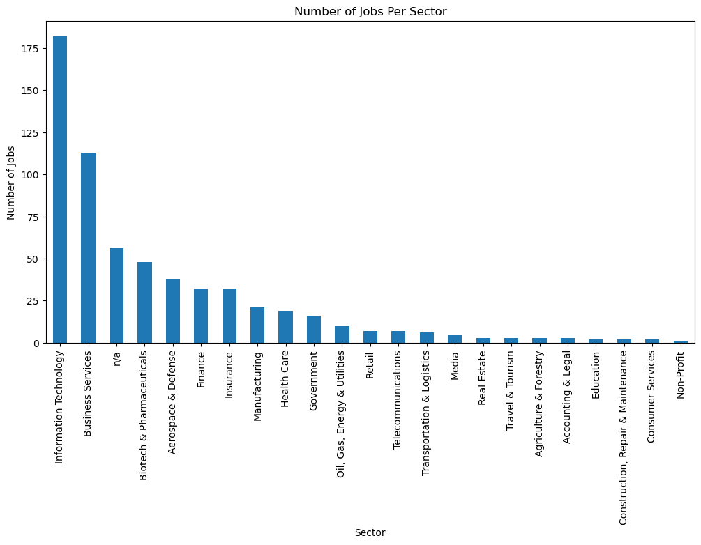

```python
# Finding out the distribution of jobs per sector
sector_counts = df['sector'].value_counts()

# Creating bar plot
plt.figure(figsize=(12, 6))
sector_counts.plot(kind='bar')

# Add labels and title
plt.xlabel('Sector')
plt.ylabel('Number of Jobs')
plt.title('Number of Jobs Per Sector')

# Show the plot
plt.show()
```

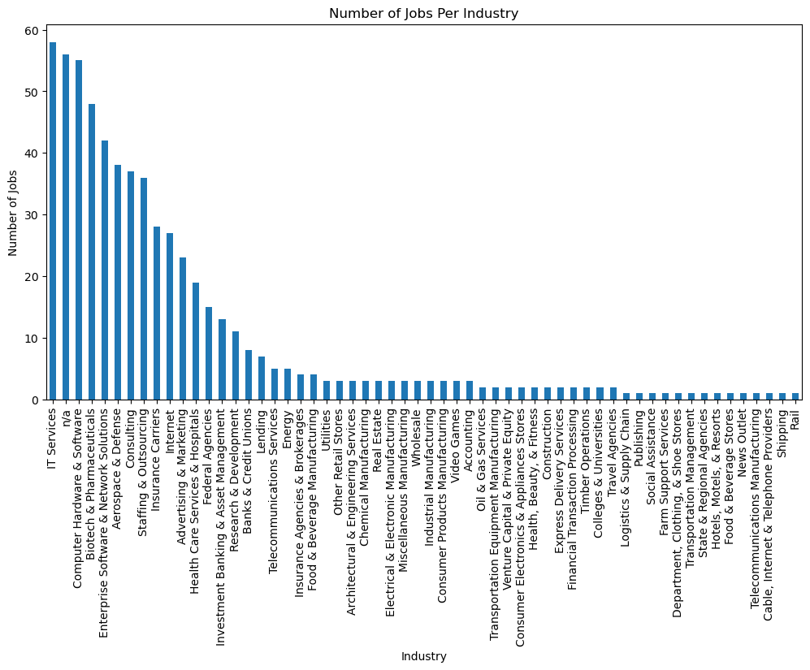

```python
# Finding out the distribution of jobs per Industry
industry_counts = df['industry'].value_counts()

# Creating bar plot
plt.figure(figsize=(12, 6))
industry_counts.plot(kind='bar')

# Add labels and title
plt.xlabel('Industry')
plt.ylabel('Number of Jobs')
plt.title('Number of Jobs Per Industry')

# Show the plot
plt.show()
```

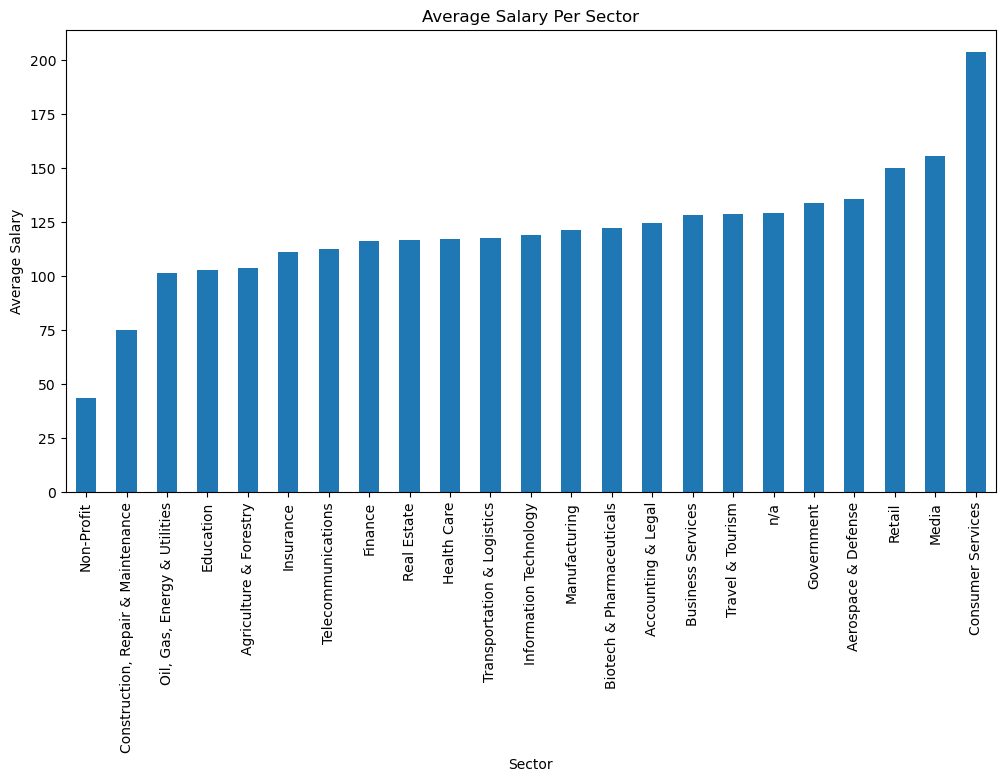

```python
# Grouping data by sector and calculating the average salary
average_salary_per_sector = df.groupby('sector')['average_salary'].mean()

# Creating bar plot
plt.figure(figsize=(12, 6))
average_salary_per_sector.sort_values().plot(kind='bar')

# Add labels and title
plt.xlabel('Sector')
plt.ylabel('Average Salary')
plt.title('Average Salary Per Sector')

# Show the plot
plt.show()
```

[figure not shown]

```python
# Grouping data by Industry and calculating the average salary
average_salary_per_industry = df.groupby('industry')['average_salary'].mean()

# Creating bar plot
plt.figure(figsize=(12, 6))
average_salary_per_industry.sort_values().plot(kind='bar')

# Add labels and title
plt.xlabel('Industry')
plt.ylabel('Average Salary')
plt.title('Average Salary Per Sector')

# Show the plot
plt.show()
```

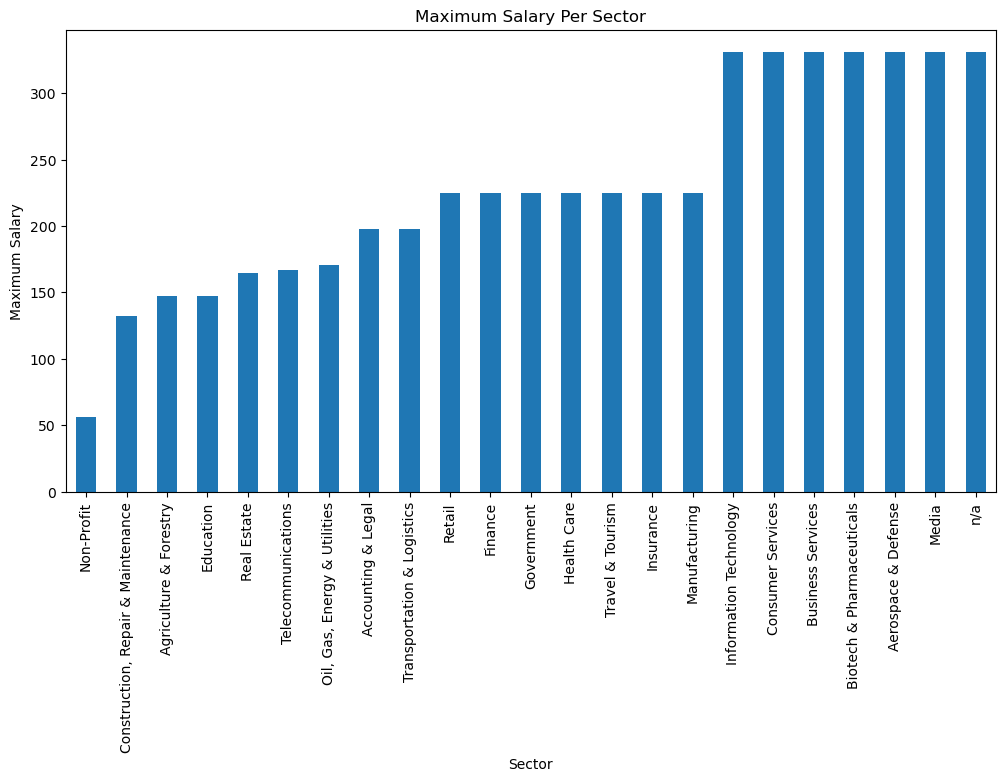

```python
# Grouping data by sector and calculating the maximum salary
max_salary_per_sector = df.groupby('sector')['maximum_salary'].max()

# Creating bar plot
plt.figure(figsize=(12, 6))
max_salary_per_sector.sort_values().plot(kind='bar')

# Add labels and title
plt.xlabel('Sector')
plt.ylabel('Maximum Salary')
plt.title('Maximum Salary Per Sector')

# Show the plot
plt.show()
```

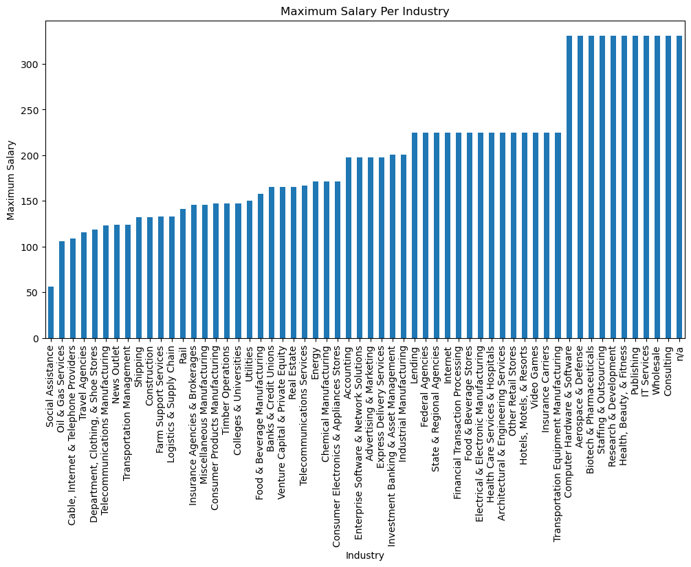

```python
# Grouping data by Industry and calculating the maximum salary
max_salary_per_industry = df.groupby('industry')['maximum_salary'].max()

# Creating bar plot
plt.figure(figsize=(12, 6))
max_salary_per_industry.sort_values().plot(kind='bar')

# Add labels and title
plt.xlabel('Industry')
plt.ylabel('Maximum Salary')
plt.title('Maximum Salary Per Industry')

# Show the plot
plt.show()
```

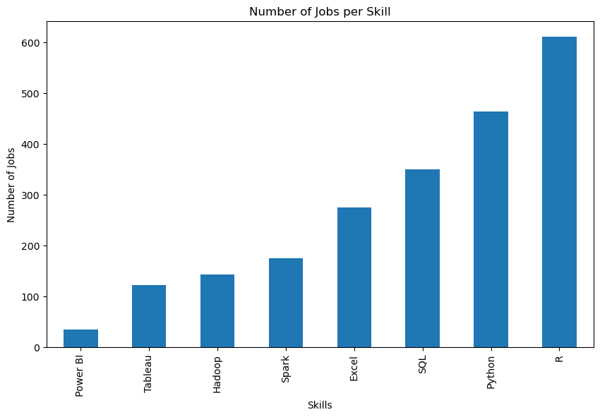

```python
# Job Skills
skills = ['R','Python','Excel','SQL','Tableau', 'Power BI','Hadoop', 'Spark']

jobs_skill = df[skills].sum()

# Creating bar plot
plt.figure(figsize=(10, 6))
jobs_skill.sort_values().plot(kind='bar')

# Adding labels and title
plt.xlabel('Skills')
plt.ylabel('Number of Jobs')
plt.title('Number of Jobs per Skill')

# Show the plot
plt.show()
```

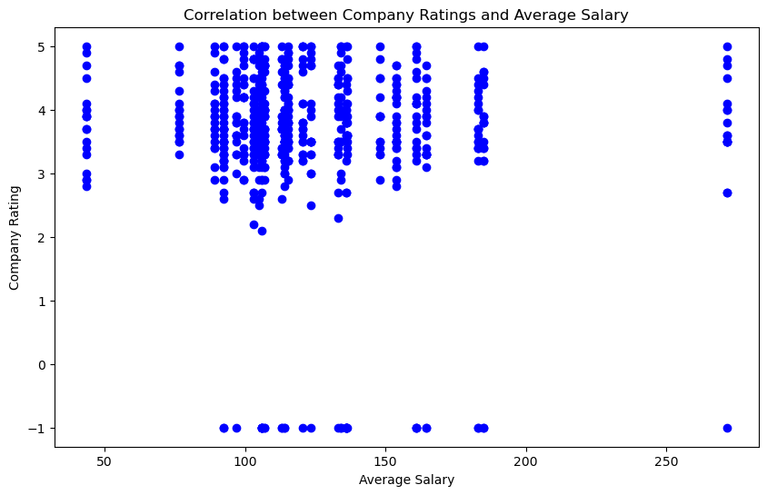

```python
# scatter plot
plt.figure(figsize=(10, 6))
plt.scatter(df['average_salary'],df['rating'], color='blue')

# Adding labels and title
plt.xlabel('Average Salary')
plt.ylabel('Company Rating')
plt.title('Correlation between Company Ratings and Average Salary')

# Show the plot
plt.show()
```

The Information Technology sector has the highest number of jobs posting, so I highly recommend that data scientists, data analyst apply more jobs in this sector.